# Stock Trading App Tutorial Part 13-15

## Part 13: [Shorting Breakdowns](https://www.youtube.com/watch?v=gsy7ROdcg4o&list=PLvzuUVysUFOuoRna8KhschkVVUo2E2g6G&index=14)

- Want to enter short side of market in the event of sustained downtrend with opening range breakdown.

### Daylight Savings Time

- Last video notes that Daylight Savings Time from timezone offset threw off calculations of `after_opening_trade_mask` in `opening_range_breakout.py` (e.g. "09:30:00-04:00" to "09:30:00-05:00") -> Suboptimal trading.
- Resolve with `timezone.py`.

(https://gist.github.com/dpapathanasiou/09bd2885813038d7d3eb) - Function `is_dst()` provides boolean on whether Daylight Savings Time is applied or not.

```
current_date = datetime.date.today().isoformat()
if is_dst():
    start_minute_bar = f"{current_date} 09:30:00-05:00"
    end_minute_bar = f"{current_date} 09:45:00-05:00"
else:
    start_minute_bar = f"{current_date} 09:30:00-04:00"
    end_minute_bar = f"{current_date} 09:45:00-04:00"
```

### `opening_range_breakdown.py`

- Copy and modify from `opening_range_breakout.py`.

```
# ...
cursor.execute("""
    SELECT id FROM strategy WHERE name = "opening_range_breakdown"
""")
strategy_id = cursor.fetchone()["id"]
# ...
    # After first 15 minutes
    after_opening_range_mask = minute_bars.index >= end_minute_bar
    after_opening_range_bars = minute_bars.loc[after_opening_range_mask]
    after_opening_bar_breakdown = after_opening_range_bars[after_opening_range_bars["close"] < opening_range_low]

    if not after_opening_bar_breakdown.empty:
        if symbol not in existing_order_symbols:
            limit_price = after_opening_bar_breakdown.iloc[0]["close"]
            print(limit_price)
            print(f"Selling short {symbol} at {limit_price}, closed below {opening_range_low} at {after_opening_bar_breakdown.iloc[0]}")

            messages.append(f"Selling short {symbol} at {limit_price}, closed below {opening_range_low}\n\n{after_opening_bar_breakdown.iloc[0]}\n\n")

            api.submit_order(
                symbol=symbol,
                side='sell',
                type='limit',
                qty='100',
                time_in_force='day',
                order_class='bracket',
                limit_price=limit_price,
                take_profit=dict(limit_price=limit_price - opening_range,),
                stop_loss=dict(limit_price=limit_price + opening_range,)
            )
        else:
            print(f"Already an order for {symbol}, will skip.")
```

- Note: Some stocks cannot be sold short; will need new `shortable` column in `stock` database.

```
cursor.executescript("""
    CREATE TABLE IF NOT EXISTS stock (
        id INTEGER PRIMARY KEY,
        symbol TEXT NOT NULL UNIQUE,
        name TEXT NOT NULL,
        exchange TEXT NOT NULL,
        shortable BOOLEAN NOT NULL
    );
""")
# ...
```

```
for asset in assets:
    # print(asset)
    try:
        if (asset.status == "active") and (asset.tradable) and (asset.symbol not in symbols): # To avoid overlaps with inactive ones; want only info of interest
            print(f"Added a new stock {asset.symbol} {asset.name}")
            cursor.execute("INSERT INTO stock (symbol, name, exchange, shortable) VALUES (?, ?, ?, ?)", (asset.symbol, asset.name, asset.exchange, asset.shortable))
    except Exception as e:
        print(asset.symbol) # symbol was set to be unique
        print(e)
```

## Part 14: [Profits, RSI/SMA Filter, Order History, Navbar](https://www.youtube.com/watch?v=5akPvvmT1nA&list=PLvzuUVysUFOuoRna8KhschkVVUo2E2g6G&index=15)

- Want to create cron scripts for `opening_range_breakout.py` and `opening_range_breakdown.py`
  - Set to only trade during similar times as regular market hours.

```
cron
*/1 21-23 * * 1-5 /usr/bin/python3 /Users/student/Documents\ –\ SNG058/Self-Learning/Algo\ Trading\ Models/Stock\ Trading\ App\ Tutorial/opening_range_breakout.py >> /Users/student/Documents\ –\ SNG058/Self-Learning/Algo\ Trading\ Models/Stock\ Trading\ App\ Tutorial/trade.log 2>&1
*/1 21-23 * * 1-5 /usr/bin/python3 /Users/student/Documents\ –\ SNG058/Self-Learning/Algo\ Trading\ Models/Stock\ Trading\ App\ Tutorial/opening_range_breakdown.py >> /Users/student/Documents\ –\ SNG058/Self-Learning/Algo\ Trading\ Models/Stock\ Trading\ App\ Tutorial/trade.log 2>&1
```

### Results (November 3 2020)

[figure not shown]

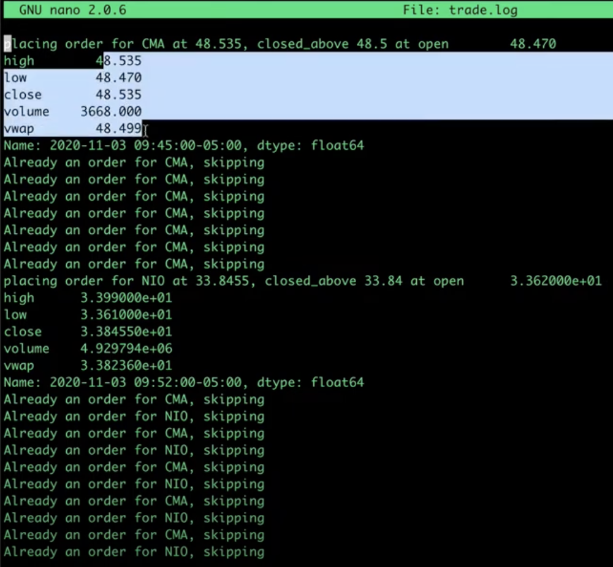

### Filters for TA-lib indicators

- May want to have input of overbought/oversold values; default will be 70 and 30.
- `index.html`

```
<h1 class="ui center aligned header">Stock List</h1>
<form method="get">
    <select name="filter">
        <option value="">All Stocks</option>
        <option
        {% if request.query_params.filter == "new_intraday_highs" %} selected="selected" {% endif %}
        value="new_intraday_highs">New Intraday Highs</option>
        <option
        {% if request.query_params.filter == "new_closing_highs" %} selected="selected" {% endif %}
        value="new_closing_highs">New Closing Highs</option>
        <option
        {% if request.query_params.filter == "new_intraday_lows" %} selected="selected" {% endif %}
        value="new_intraday_lows">New Intraday Lows</option>
        <option
        {% if request.query_params.filter == "new_closing_lows" %} selected="selected" {% endif %}
        value="new_closing_lows">New Closing Lows</option>
        {% if request.query_params.filter == "rsi_overbought" %} selected="selected" {% endif %}
        value="rsi_overbought">RSI Overbought</option>
        {% if request.query_params.filter == "rsi_oversold" %} selected="selected" {% endif %}
        value="rsi_oversold">RSI Oversold</option>
    </select>
    <input type="submit"/>
</form>
```

- `main.py`

```
@app.get("/")
def index(request: Request):
    # ...
    if stock_filter == "new_intraday_highs":
        pass
    # ...
    elif stock_filter == "rsi_overbought":
        cursor.execute("""
            SELECT symbol, name, stock_id, min(close), date
            FROM stock_price JOIN stock ON stock.id = stock_price.stock_id
            WHERE rsi_14 > 70 AND date = (SELECT max(date) FROM stock_price)
            ORDER BY symbol
        """)
    elif stock_filter == "rsi_oversold":
        cursor.execute("""
            SELECT symbol, name, stock_id, min(close), date
            FROM stock_price JOIN stock ON stock.id = stock_price.stock_id
            WHERE rsi_14 < 30 AND date = (SELECT max(date) FROM stock_price)
            ORDER BY symbol
        """)
    elif stock_filter == "above_sma_20":
        cursor.execute("""
            SELECT symbol, name, stock_id, min(close), date
            FROM stock_price JOIN stock ON stock.id = stock_price.stock_id
            WHERE close > sma_20 AND date = (SELECT max(date) FROM stock_price)
            ORDER BY symbol
        """)
    elif stock_filter == "below_sma_20":
        cursor.execute("""
            SELECT symbol, name, stock_id, min(close), date
            FROM stock_price JOIN stock ON stock.id = stock_price.stock_id
            WHERE close < sma_20 AND date = (SELECT max(date) FROM stock_price)
            ORDER BY symbol
        """)
    elif stock_filter == "above_sma_50":
        cursor.execute("""
            SELECT symbol, name, stock_id, min(close), date
            FROM stock_price JOIN stock ON stock.id = stock_price.stock_id
            WHERE close > sma_50 AND date = (SELECT max(date) FROM stock_price)
            ORDER BY symbol
        """)
    elif stock_filter == "below_sma_50":
        cursor.execute("""
            SELECT symbol, name, stock_id, min(close), date
            FROM stock_price JOIN stock ON stock.id = stock_price.stock_id
            WHERE close < sma_50 AND date = (SELECT max(date) FROM stock_price)
            ORDER BY symbol
        """)
```

### Navbar to link all screens together

- https://semantic-ui.com/collections/menu.html
- Apply to `layout.html`, want to apply that to `index.html`.
- `layout.html`

```
<body>
    <div class="ui secondary pointing menu">
        <a href="/" class="item active">Stocks</a>
        <a href="/strategies" class="item">Strategies</a>
        <a href="/orders" class="item">Order History</a>
        <div class="right menu">
            <a class="ui item">Logout</a>
        </div>
    </div>
    <div class="ui container">
        {% block content %}
        {% endblock %}
    </div>
</body>
```

### Display order history and strategy list

- Get list of strategies from `strategy` table.
- Order history has to obtained through Alpaca, ideally load page then have JavaScript fetch it.
- `main.py`

```
@app.get("/strategies")
def strategies(request: Request):
    connection = sqlite3.connect(config.DB_FILE)
    connection.row_factory = sqlite3.Row
    cursor = connection.cursor()
    cursor.execute("""
        SELECT * FROM strategies
    """)
    strategies = cursor.fetchall()
    return templates.TemplateResponse("strategies.html", context={"request": request, "strategies": strategies})

@app.get("/orders")
def orders(request: Request):
    api = tradeapi.REST(config.API_KEY, config.SECRET_KEY, base_url = config.API_URL, api_version = "v2") # config.py variables
    orders = api.list_orders(status="all")
    return templates.TemplateResponse("orders.html", context={"request": request, "orders": orders})
```

- `strategies.html`

```
{% extends "layout.html" %}
{% block content %}
    <h1>Strategies</h1>
    <table class="ui selectable striped table">
        {% for strategy in strategies %}
        <tr>
            <td><a href="/strategy/{{ strategy.id }}">{{ strategy.name }}</a></td>
        </tr>
        {% endfor %}
    </table>
{% endblock %}
```

- `orders.html`
  - Each order is dictionary, will use `created_at`, `side`, `filled_qty`, `symbol`, `filled_avg_price`, `status`.

```
{% extends "layout.html" %}
{% block content %}
    <h1>Orders</h1>
    <table class="ui selectable striped table">
        <thead>
            <td>Created</td>
            <td>Side</td>
            <td>Quantity</td>
            <td>Symbol</td>
            <td>Price</td>
            <td>Status</td>
        </thead>
        {% for order in orders %}
        <tr>
            <td>{{ order.created_at }}</td>
            <td>{{ order.side }}</td>
            <td>{{ order.filled_qty }}</td>
            <td>{{ order.symbol }}</td>
            <td>{{ order.filled_avg_price }}</td>
            <td>{{ order.status }}</td>
        </tr>
        {% endfor %}
    </table>
{% endblock %}
```

## Part 15: [Bollinger Bands, Intraday Tulip Indicators](https://www.youtube.com/watch?v=ISRFK-svbWk&list=PLvzuUVysUFOuoRna8KhschkVVUo2E2g6G&index=16)

### Bollinger Bands

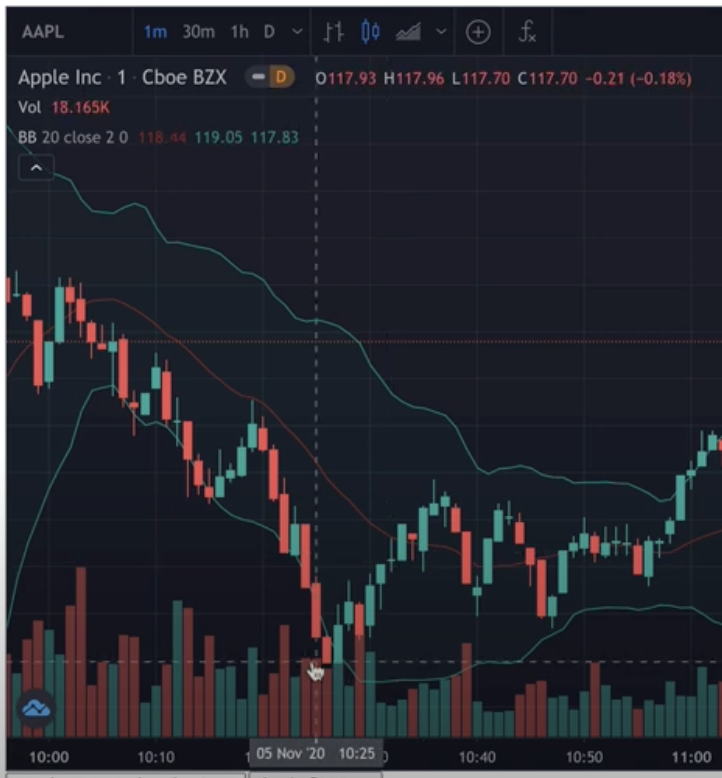

- Add new strategy to `strategy` table:

`INSERT INTO strategy (name) VALUES ("bollinger_bands");`

- `bollinger_bands.py`
  - Will run every minute, check candles, may execute trades.
  - Use `opening_range_breakout.py` as reference.
  - `upper, middle, lower = talib.BBANDS(...)` for bollinger band values.

```
import sqlite3
import config
import alpaca_trade_api as tradeapi
import datetime
import pytz
import pandas as pd
from timezone import is_dst
from get_minute_data import get_minute_data
# import smtplib, ssl # Notifications
import talib

connection = sqlite3.connect(config.DB_FILE)
connection.row_factory = sqlite3.Row
cursor = connection.cursor()

cursor.execute("""
    SELECT id FROM strategy WHERE name = "bollinger_bands"
""")
strategy_id = cursor.fetchone()["id"]

cursor.execute("""
    SELECT symbol, name
    FROM stock JOIN stock_strategy ON stock_strategy.stock_id = stock.id
    WHERE stock_strategy.strategy_id = ?
""", (strategy_id, ))
stocks = cursor.fetchall()
symbols = [stock["symbol"] for stock in stocks] # Obtain stock symbols of interest

api = tradeapi.REST(config.API_KEY, config.SECRET_KEY, base_url = config.API_URL, api_version = "v2") # config.py variables

# current_date = datetime.date.today().isoformat()
current_date = datetime.datetime.strptime("2022-06-21", '%Y-%m-%d').date()

start_minute_bar = pd.to_datetime(f"{current_date} 09:30:00", utc = False).tz_localize('US/Eastern')
end_minute_bar = pd.to_datetime(f"{current_date} 16:00:00", utc = False).tz_localize('US/Eastern')

orders = api.list_orders(status="all", after=f"{current_date}T13:30:00Z")
# existing_order_symbols = [order.symbol for order in orders]
existing_order_symbols = [order.symbol for order in orders if order.status != "canceled"]

messages = []
# print(symbols)

for symbol in symbols:
    # minute_bars = api.polygon.historic_agg_v2(symbol, 1, "minute", _from = current_date, to = current_date).df # CANNOT BE APPLIED DUE TO NEEDING POLYGON
    minute_bars = get_minute_data(symbol).tz_localize('US/Eastern') # Fetch minute bars for each stock symbol
    print(minute_bars.index) # ['2024-07-15 07:07:00', '2024-07-15 07:11:00', ...]

    # Obtain first 15 minutes
    market_open_mask = (minute_bars.index >= start_minute_bar) & (minute_bars.index < end_minute_bar)
    market_open_bars = minute_bars.loc[market_open_mask]
    # print(market_open_bars)

    if len(market_open_bars) >= 20:
        # closes = market_open_bars["close"].values
        closes = market_open_bars.close.values
        # print(closes)

        upper, middle, lower = talib.BBANDS(closes, 20, 2, 2)
        current_candle = market_open_bars.iloc[-1]
        previous_candle = market_open_bars.iloc[-2]

        if current_candle.close > lower[-1] and previous_candle.close < lower[-2]:
            print(f"{symbol} closed above lower Bollinger band")
            print(current_candle)

            if symbol not in existing_order_symbols:
                limit_price = current_candle.close
                candle_range = current_candle.high - current_candle.close
                print(f"Placing order for {symbol} at {limit_price}, closed above {opening_range_high} at {after_opening_bar_breakout.iloc[0]}")

                messages.append(f"Placing order for {symbol} at {limit_price}")

                try:
                    api.submit_order(
                        symbol=symbol,
                        side='buy',
                        type='limit',
                        qty='100',
                        time_in_force='day',
                        order_class='bracket',
                        limit_price=limit_price,
                        take_profit=dict(
                            limit_price=limit_price + (candle_range * 3),
                        ),
                        stop_loss=dict(
                            stop_price=previous_candle.low,
                        )
                    )
                except Exception as e:
                    print(f"Cannot submit order {e}")
            else:
                print(f"Already an order for {symbol}, will skip.")
```